## Course: VISUAL ANALYTICS FOR POLICY AND MANAGEMENT

### Prof. José Manuel Magallanes, PhD

- Visiting Professor of Computational Policy at Evans School of Public Policy and Governance, and eScience Institute Senior Data Science Fellow, University of Washington.
- Professor of Government and Political Methodology, Pontificia Universidad Católica del Perú.

# Session 2: Tabular data- Univariate Categorical

Contents:

1. Tabular Data.
2. Data Types.
3. Categorical Data.
   - Nominal Data.
   - Ordinal Data.

# Tabular Data

Most data are commonly organized in tabular format, that is, tables. When data is in tabular format, cases are organized in rows, while variables (information about the cases) are organized in columns. Almost every data you have used in a spreadsheet follows that structure.

For example, when you visit the [website](https://nces.ed.gov/ccd/) of the Common Core of Data from the US Department of Education, you can get a data set with detailed information on public schools from the whole US. Let me get a data table I have prepared with schools from the State of Washington:

```r
location='https://github.com/EvansDataScience/data/raw/master/'
file='eduwa.rda'
link=paste0(location,file)


#getting the data TABLE from the file in the cloud:
load(file=url(link))
```

This is the list of the 24 variables (columns) from the data loaded:

```r
names(eduwa)
```

```
##  [1] "NCES.School.ID"        "State.School.ID"       "NCES.District.ID"
##  [4] "State.District.ID"     "Low.Grade"             "High.Grade"
##  [7] "School.Name"           "District"              "County"
## [10] "Street.Address"        "City"                  "State"
## [13] "ZIP"                   "ZIP.4-digit"           "Phone"
## [16] "Locale.Code"           "LocaleType"            "LocaleSub"
## [19] "Charter"               "Title.I.School"        "Title.1.School.Wide"
## [22] "Student.Teacher.Ratio" "Free.Lunch"            "Reduced.Lunch"
```

Go to table of contents.

## Data Types

Whatever your visual goals are, you first need to know how that variable you are planing to use has been recognised in R:

```r
# this 'width = 70,strict.width='cut' means
# you do not want to see more than 70 characters per row.

str(eduwa,width = 70,strict.width='cut')
```

```
## 'data.frame':    2427 obs. of  24 variables:
##  $ NCES.School.ID       : chr  "530486002475" "530270001270" "53091"..
##  $ State.School.ID      : chr  "WA-31025-1656" "WA-06114-1646" "WA-"..
##  $ NCES.District.ID     : chr  "5304860" "5302700" "5309100" "53000"..
##  $ State.District.ID    : chr  "WA-31025" "WA-06114" "WA-34033" "WA"..
##  $ Low.Grade            : Ord.factor w/ 14 levels "PK"<"KG"<"1"<..: ..
##  $ High.Grade           : Ord.factor w/ 15 levels "PK"<"KG"<"1"<..: ..
##  $ School.Name          : chr  "10th Street School" "49th Street Ac"..
##  $ District             : chr  "Marysville School District" "Evergr"..
##  $ County               : chr  "Snohomish" "Clark" "Thurston" "Gray"..
##  $ Street.Address       : chr  "7204 27th Ave NE" "14619B NE 49th S"..
##  $ City                 : chr  "Marysville" "Vancouver" "Tumwater" "..
##  $ State                : chr  "WA" "WA" "WA" "WA" ...
##  $ ZIP                  : chr  "98271" "98682" "98512" "98520" ...
##  $ ZIP.4-digit          : chr  NA "6308" NA "5510" ...
##  $ Phone                : chr  "(360)965-0400" "(360)604-6700" "(36"..
##  $ Locale.Code          : Factor w/ 12 levels "11","12","13",..: 5 2..
##  $ LocaleType           : Factor w/ 4 levels "City","Rural",..: 3 1 ..
##  $ LocaleSub            : Factor w/ 12 levels "City: Small",..: 5 2 ..
##  $ Charter              : Factor w/ 2 levels "No","Yes": 1 1 1 1 1 1..
##  $ Title.I.School       : Factor w/ 2 levels "No","Yes": 2 1 1 2 1 1..
##  $ Title.1.School.Wide  : Factor w/ 2 levels "No","Yes": 2 NA NA 2 N..
##  $ Student.Teacher.Ratio: num  23.4 8.4 21.5 15.9 6.5 15.3 NA 16.3 1..
##  $ Free.Lunch           : num  28 53 169 292 12 411 48 102 101 268 ...
##  $ Reduced.Lunch        : num  3 9 40 10 4 23 12 22 23 0 ...
```

You see different data types in the result: **num** (numbers in R when decimal values are detected). The ones that say **chr** are strings. You see several variables identified as *factor* or *ordered factor*, which are categorical variables.

Go to table of contents.

## Categorical Data

The classification can propose an incremental or non-incremental differentiation. The former are named ordinal data and the latter nominal data. A nominal classification related to education can be type of school funding: public or private; while an ordinal one can be: elementary, middle, high, college and graduate school level.

### 1. Visualization for nominal variables

Let’s see some raw values in the variable **LocaleType**:

```r
head(eduwa$LocaleType,20) #first twenty values
```

```
##  [1] Suburb City   City   Town   City   City   Suburb City   Rural  Rural
## [11] City   City   City   City   Suburb Rural  Rural  Rural  Suburb City
## Levels: City Rural Suburb Town
```

You can not get a clear idea of what a data table has, so a simple **frequency table** is the first tool to see what these nominal data are telling us:

```r
# absolute values
absoluteT=table(eduwa$LocaleType,
                exclude = 'nothing') #include all values!
#here you are:
absoluteT
```

```
##
##   City  Rural Suburb   Town   <NA>
##    714    505    798    338     72
```

The absolute count can be transformed into percent or relative frequencies:

```r
# relative values
prop.table(absoluteT)
```

```
##
##       City      Rural     Suburb       Town       <NA>
## 0.29419036 0.20807581 0.32880099 0.13926658 0.02966625
```

We should try using all the information possible, then it is a good idea to *label* the missing values:

```r
names(absoluteT)[5]='Unknown'
```

If you prefer that the range of the proportions be translated into percents you can do:

```r
propT=prop.table(absoluteT)*100
#you get:
propT
```

```
##      City     Rural    Suburb      Town   Unknown
## 29.419036 20.807581 32.880099 13.926658  2.966625
```

This table tells us the location of the public schools. What is the right visual for this? Sometimes the answer seems obvious, as tradition or habits give so much weight to decisions. Let’s use the very well known **pie chart**:

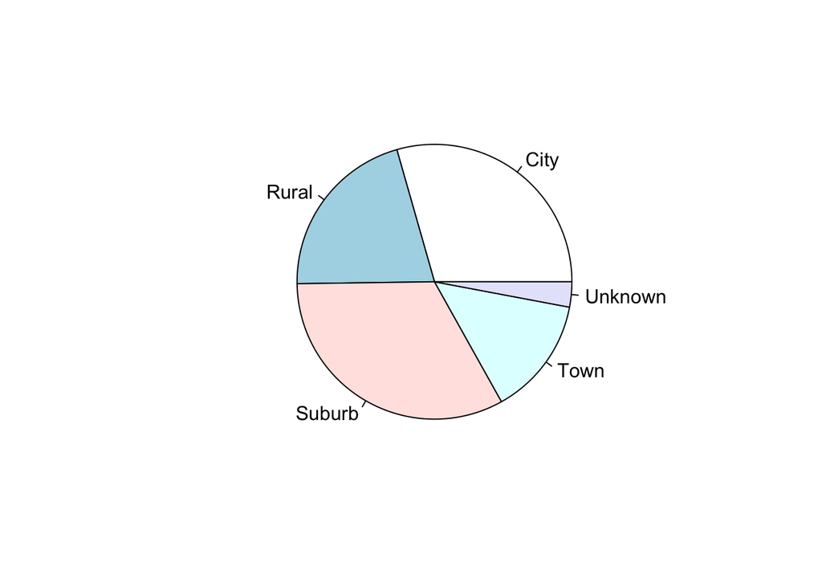

```r
# the pie plots the table:
pie(absoluteT)
```

Most people tend to use pie charts with categorical data, but this **should not** be the default option to visualize classification (see this [discussion](https://medium.com/geckoboard-under-the-hood/think-before-you-pie-chart-and-more-effective-ways-to-visualize-your-data-862ea3456b26). Let’s turn our pie into a **bar chart** using: **ggplot2**.

The basic steps to prepare a visual in ggplot2 are:

1. Turn the frequency table into a data frame:

```r
# as data frame
(tableFreq=as.data.frame(absoluteT))
```

```
##      Var1 Freq
## 1    City  714
## 2   Rural  505
## 3  Suburb  798
## 4    Town  338
## 5 Unknown   72
```

The previous frequency table can be improved:

```r
# renaming data frame columns
names(tableFreq)=c("Locale","Count")
# adding percents:
tableFreq$Percent=as.vector(propT)
# then, you have:
tableFreq
```

```
##    Locale Count   Percent
## 1    City   714 29.419036
## 2   Rural   505 20.807581
## 3  Suburb   798 32.880099
## 4    Town   338 13.926658
## 5 Unknown    72  2.966625
```

This data frame has the three columns, we will use second for our bars.

2. Call the library (you may need to install it first):

```r
library(ggplot2)
```

3. Create the **base** object, which is not a plot, just informing the main variables:

```r
#base GGPLOT2 starts with a "base", telling WHAT VARIABLES TO PLOT
base= ggplot(data = tableFreq,
             aes(x = Locale,
                 y = Count))
```

4. On top of the previous object, add the layer that produces the main plots (the next layers will add or customize elements in the plot):

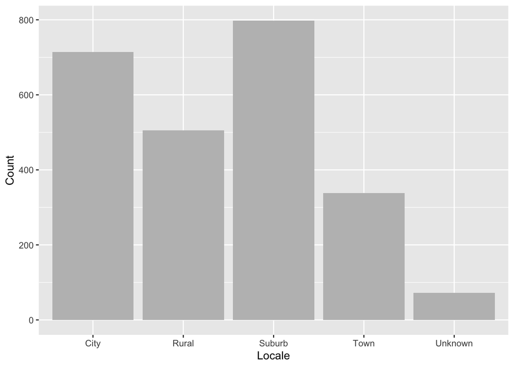

```r
plot1 = base + geom_bar(fill ="gray",
                        stat = 'identity')
plot1
```

You have a default bar plot now. From here, you start adding more layers that will change the default.

- Add titles:

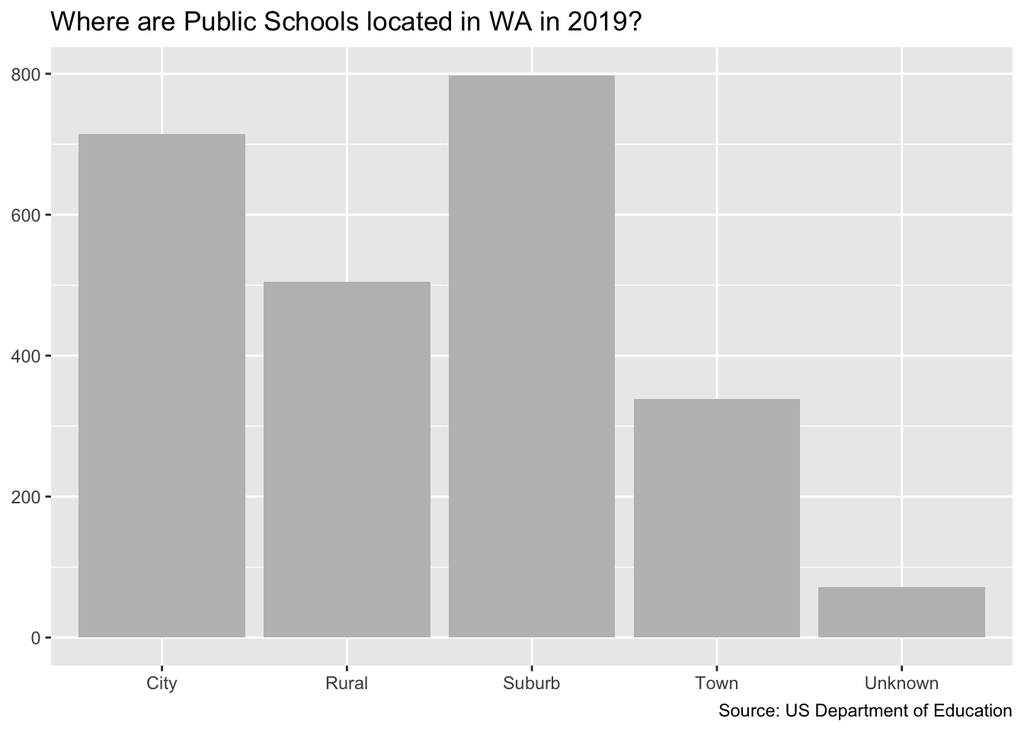

```r
titleText='Where are Public Schools located in WA in 2019?'
sourceText='Source: US Department of Education'

plot2 = plot1 + labs(title=titleText,
                     x =NULL,
                     y = NULL,
                     caption = sourceText)
plot2
```

- Add the reference lines: Let’s use the percent column and annotate to show a particular value.

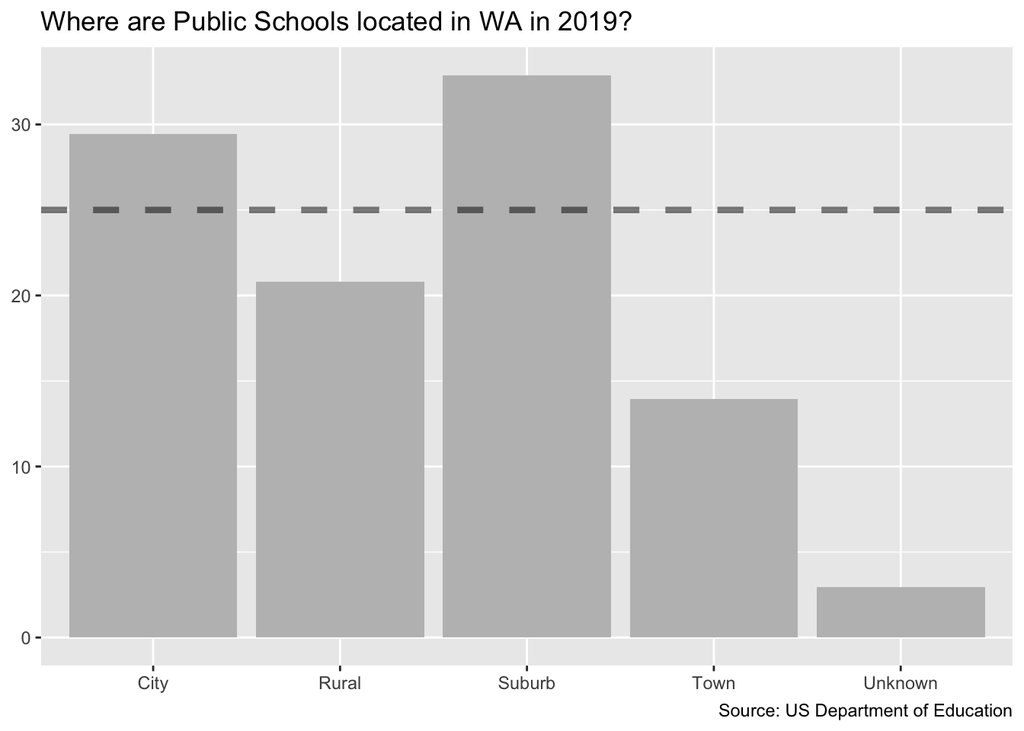

```r
base= ggplot(data = tableFreq,
             aes(x = Locale,
                 y = Percent))

plot1 = base + geom_bar(fill ="gray",
                        stat = 'identity')

plot2 = plot1 + labs(title=titleText,
                     x =NULL,
                     y = NULL,
                     caption = sourceText)

plot3 = plot2 + geom_hline(yintercept = 25, #where
                           linetype="dashed",
                           size=1.5, #thickness
                           alpha=0.5) #transparency
plot3
```

- Customize the vertical axes:

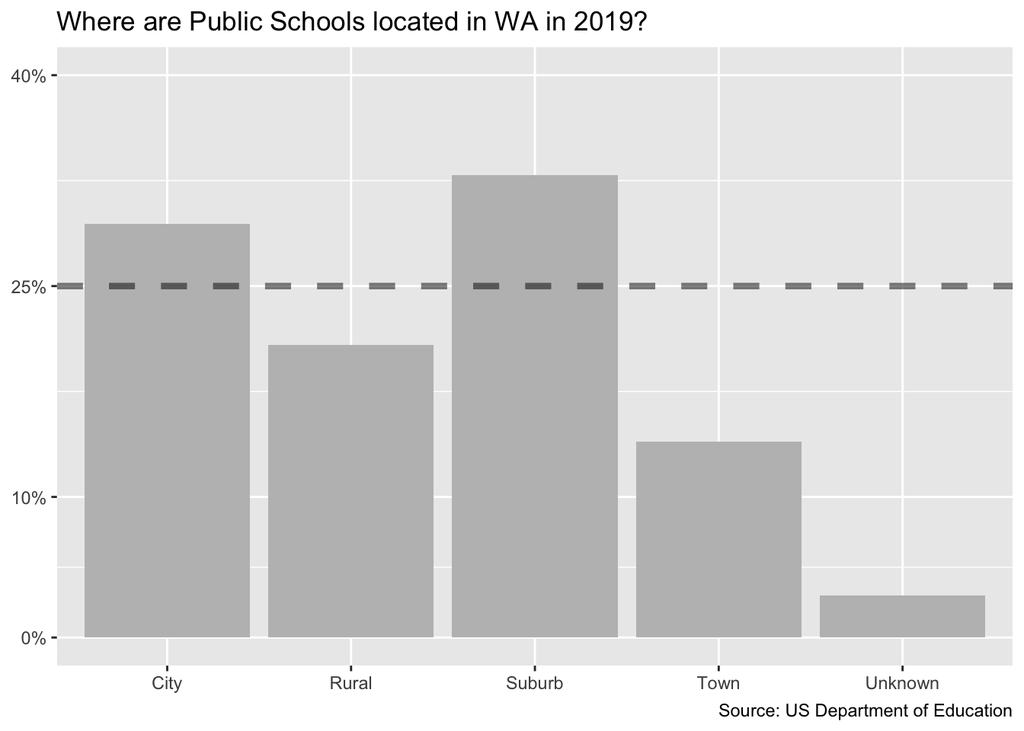

```r
library(scales) # for "unit_format""

# customize Y axis
plot4 = plot3 + scale_y_continuous(breaks=c(0,10, 25,40),
                                   limits = c(0, 40),
                                   labels=unit_format(suffix = '%'))
plot4
```

- Title/subtitle positions:

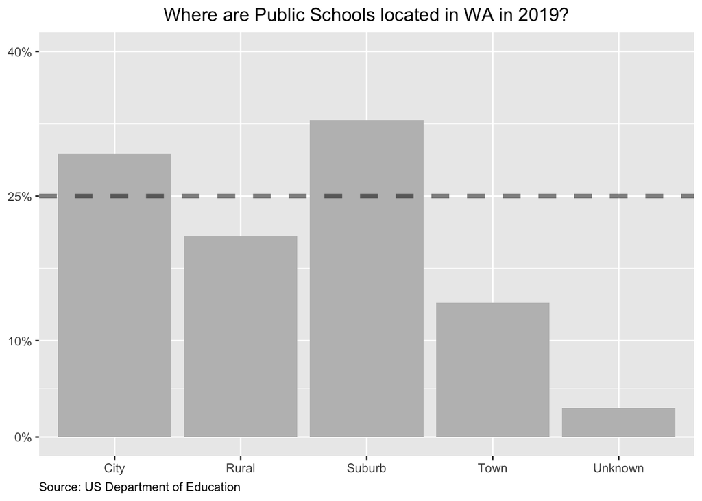

```r
#positions: 0 left / 1 right / 0.5 center
plot5 = plot4 + theme(plot.caption = element_text(hjust = 0),
                      plot.title = element_text(hjust = 0.5))
plot5
```

- Annotating the bars:

Would you like these values in the bars:

```r
paste0(round(tableFreq$Percent,2), '%')
```

```
## [1] "29.42%" "20.81%" "32.88%" "13.93%" "2.97%"
```

So, we add them:

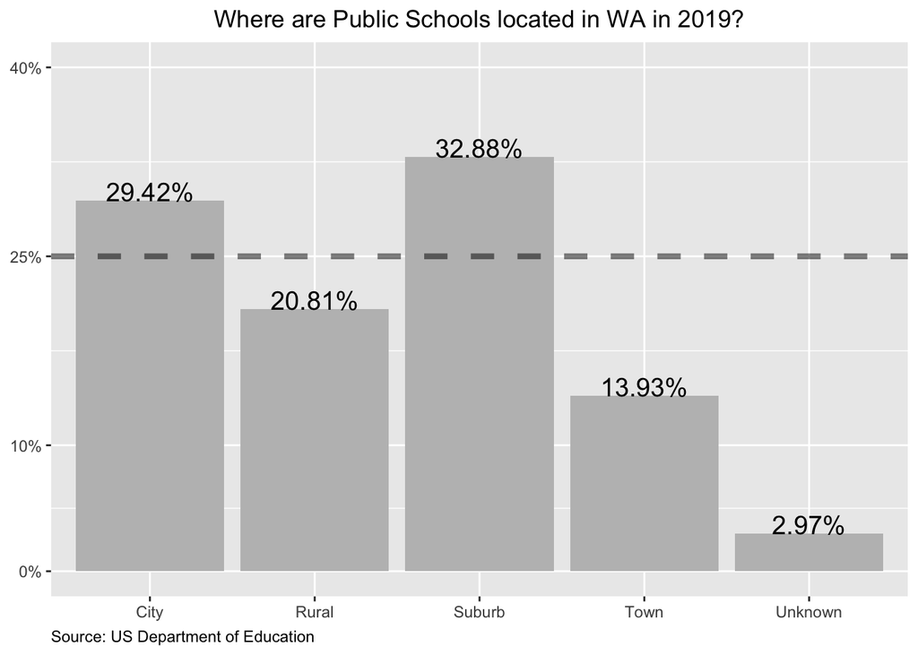

```r
# creating labels:
LABELS=paste0(round(tableFreq$Percent,2), '%')
###
plot6 = plot5 + geom_text(vjust=0, #hjust if flipping
                          size = 5,
                          aes(y = Percent ,
                              label = LABELS))
plot6# + coord_flip() # wanna flip the plot?
```

Bar plots are the default option for categorical variables. In general, you see the distribution of the classification, which allows you to identify **concentration**. For that reason, ordering the bars by height can be helpful:

```r
tableFreq=tableFreq[order(tableFreq$Percent),]
# then:
tableFreq
```

```
##    Locale Count   Percent
## 5 Unknown    72  2.966625
## 4    Town   338 13.926658
## 2   Rural   505 20.807581
## 1    City   714 29.419036
## 3  Suburb   798 32.880099
```

Let’s save the order of *locale*:

```r
(localesOrd=tableFreq[order(tableFreq$Percent),'Locale'])
```

```
## [1] Unknown Town    Rural   City    Suburb
## Levels: City Rural Suburb Town Unknown
```

You may also need to reduce more the data-ink ratio, so I recommend changing the theme to **classic**. This and the object *localesOrd* can be added to the previous base:

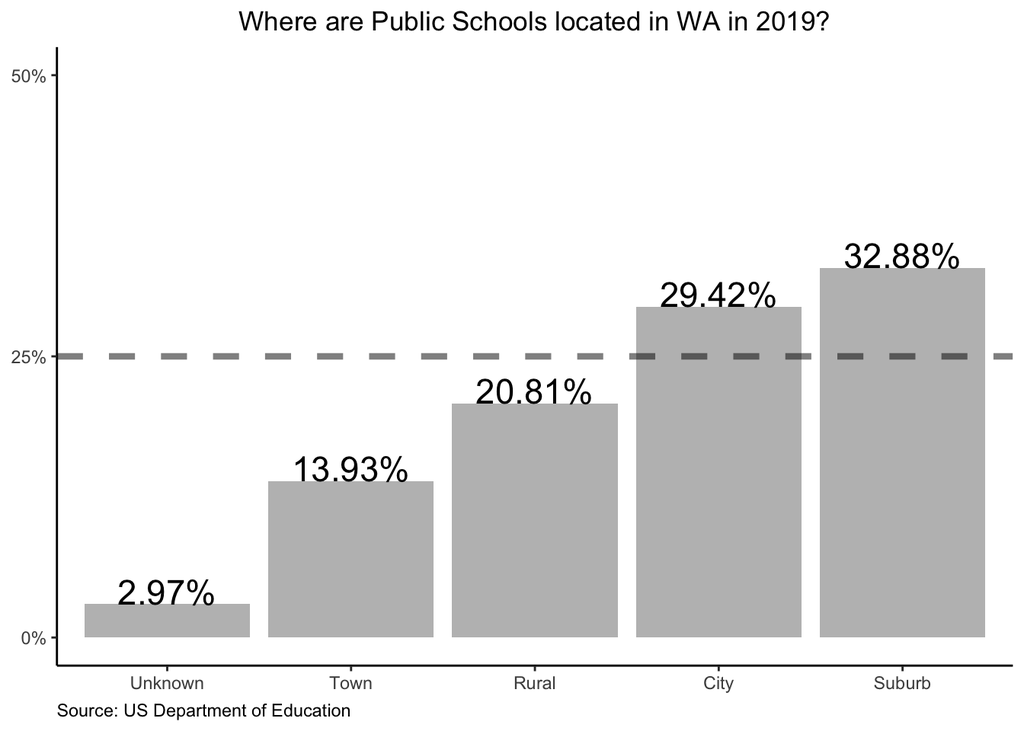

```r
# redo:
LABELS=paste0(round(tableFreq$Percent,2), '%')
base= ggplot(data = tableFreq,
             aes(x = Locale,y = Percent))
## adding these to base
base= base + scale_x_discrete(limits=localesOrd)
base= base + theme_classic()
##
plot1 = base + geom_bar(fill ="gray",
                        stat = 'identity')
plot2 = plot1 + labs(title=titleText,
                     x =NULL,
                     y = NULL,
                     caption = sourceText)
plot3 = plot2 + geom_hline(yintercept = 25,
                           linetype="dashed",
                           size=1.5,
                           alpha=0.5)
plot4 = plot3 + scale_y_continuous(breaks=c(0,25,50),
                                 limits = c(0, 50),
                                 # expand = c(0, 0), #try?
                            labels=unit_format(suffix = '%'))

plot5 = plot4 + theme(plot.caption = element_text(hjust = 0),
                      plot.title = element_text(hjust = 0.5))


plot6 = plot5 + geom_text(vjust=0, #hjust if flipping
                          size = 6,#fontface = "bold",
                          aes(y = Percent,
                              label = LABELS))
plot6 #+ coord_flip() # wanna flip the plot?
```

Once you have the bar plot, you can explore **alternative** visuals. For example, we could use our reference line to show gaps or differences. In this case, the **Lollipop** plot may be useful. This one is just a replacement for a bar plot:

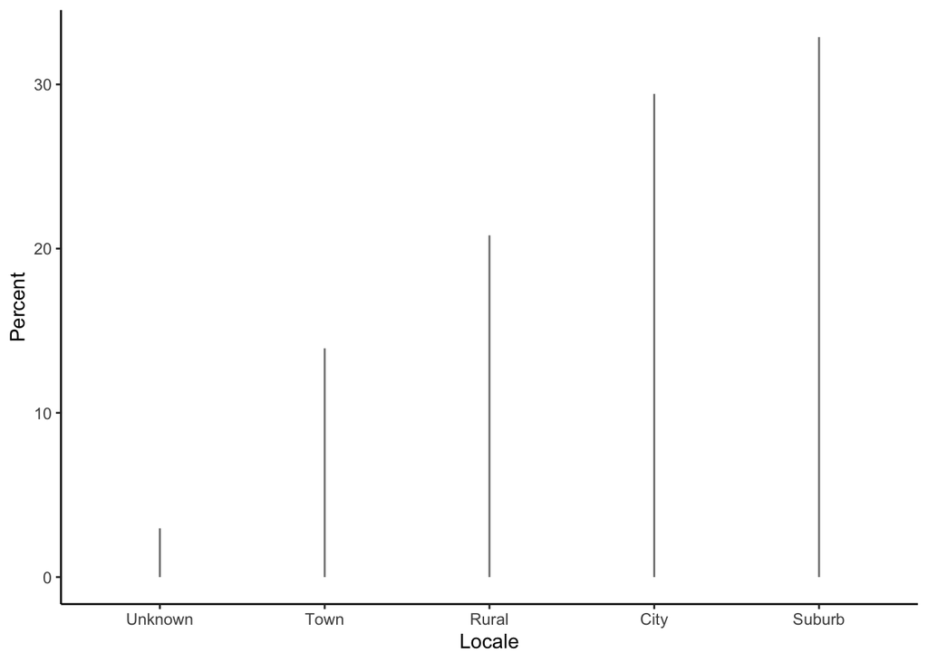

```r
#familiar
base = ggplot(tableFreq, aes(Locale,Percent))
base = base + theme_classic()
base = base + scale_x_discrete(limits=localesOrd)
#new:geom_segment
lolliplot1=base + geom_segment(aes(y = 0,
                                   x = Locale,
                                   yend = Percent,
                                   xend = Locale),
                               color = "grey50")
lolliplot1
```

The candy is missing:

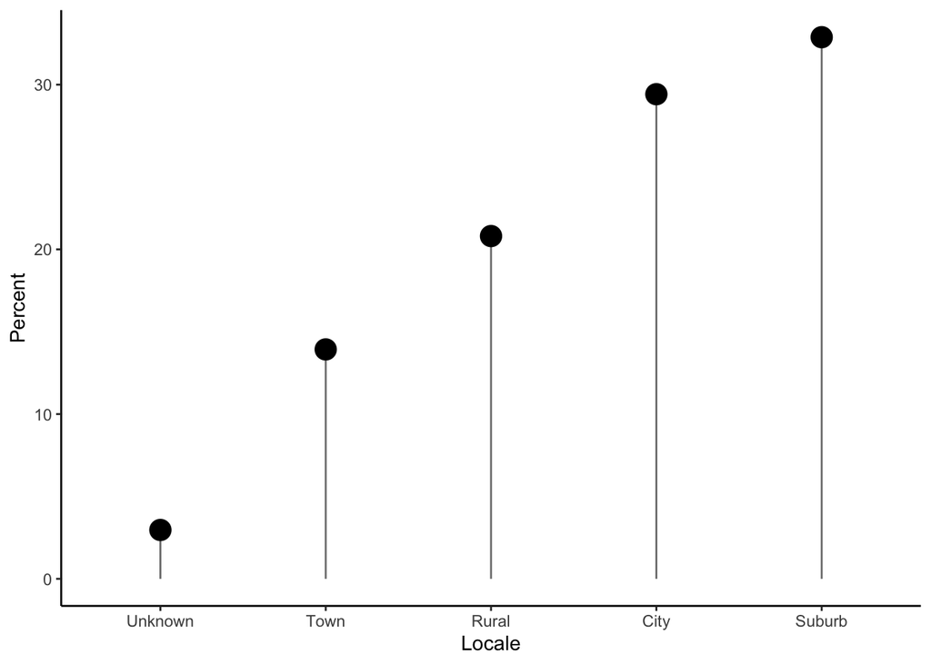

```r
lolliplot2=lolliplot1 + geom_point(size=5)
lolliplot2
```

And, what about changing the axis values so that we can identify the gaps:

```r
# new variable
tableFreq$gap=tableFreq$Percent-25
tableFreq
```

```
##    Locale Count   Percent        gap
## 5 Unknown    72  2.966625 -22.033375
## 4    Town   338 13.926658 -11.073342
## 2   Rural   505 20.807581  -4.192419
## 1    City   714 29.419036   4.419036
## 3  Suburb   798 32.880099   7.880099
```

That will be our new **y** in **aes**:

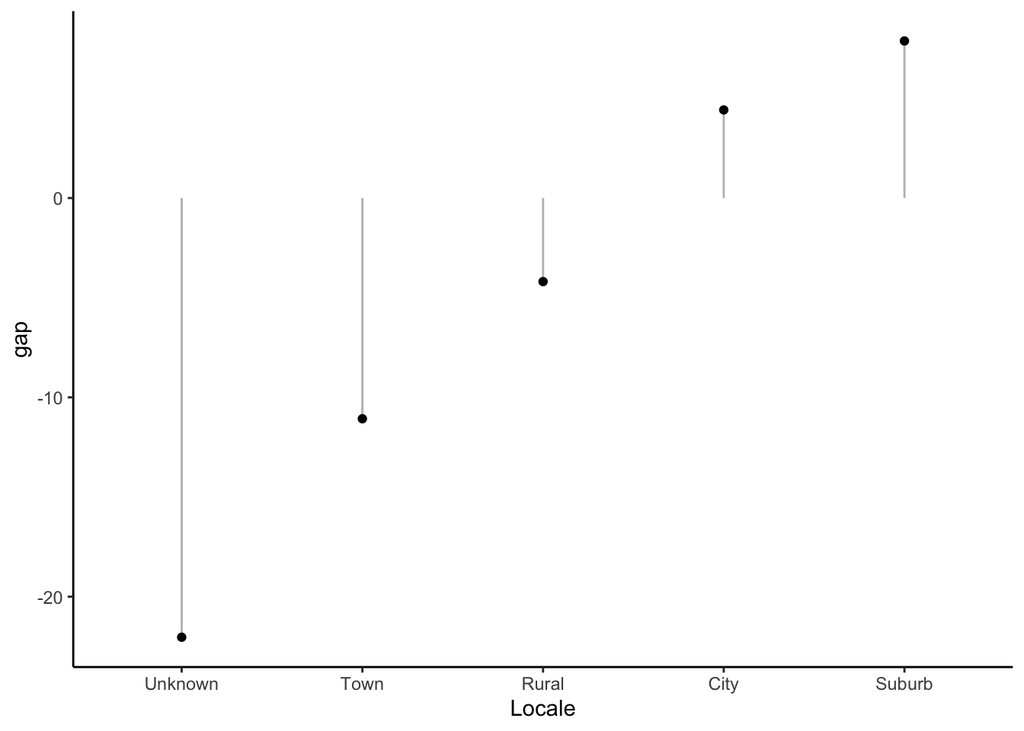

```r
base = ggplot(tableFreq, aes(x=Locale,
                             y=gap)) #change
base = base + theme_classic()
base = base + scale_x_discrete(limits=localesOrd)

lolliplot1=base + geom_segment(aes(y = 0,
                                   yend = gap, #change
                                   x = Locale,
                                   xend = Locale),
                               color = "gray")
lolliplot2 = lolliplot1 + geom_point()
lolliplot2
```

Maybe add some color, for that we need to create a new categorical column:

```r
# a new column for color
tableFreq$PositiveGap=ifelse(tableFreq$gap>0,"Yes","No")
tableFreq
```

```
##    Locale Count   Percent        gap PositiveGap
## 5 Unknown    72  2.966625 -22.033375          No
## 4    Town   338 13.926658 -11.073342          No
## 2   Rural   505 20.807581  -4.192419          No
## 1    City   714 29.419036   4.419036         Yes
## 3  Suburb   798 32.880099   7.880099         Yes
```

That will the **color** in **aes**:

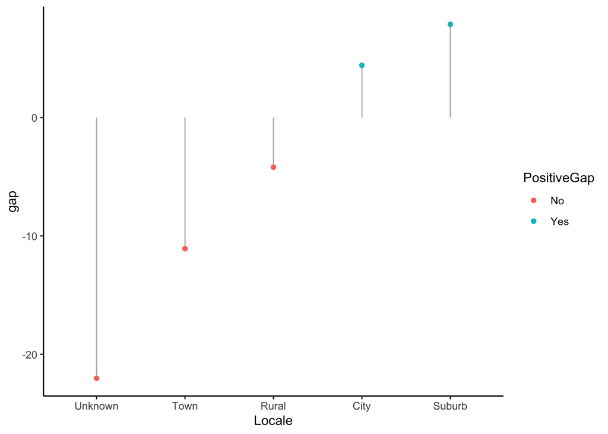

```r
# add new aesthetics 'color'
base = ggplot(tableFreq, aes(x=Locale,
                             y=gap,
                             color=PositiveGap))#here
base = base + theme_classic()
base= base + scale_x_discrete(limits=localesOrd)

lolliplot1=base + geom_segment(aes(y = 0,
                                   yend = gap,
                                   x = Locale,
                                   xend = Locale),
                               color = "gray")

lolliplot2 = lolliplot1 + geom_point()

lolliplot2
```

Maybe add a **label** in **aes**:

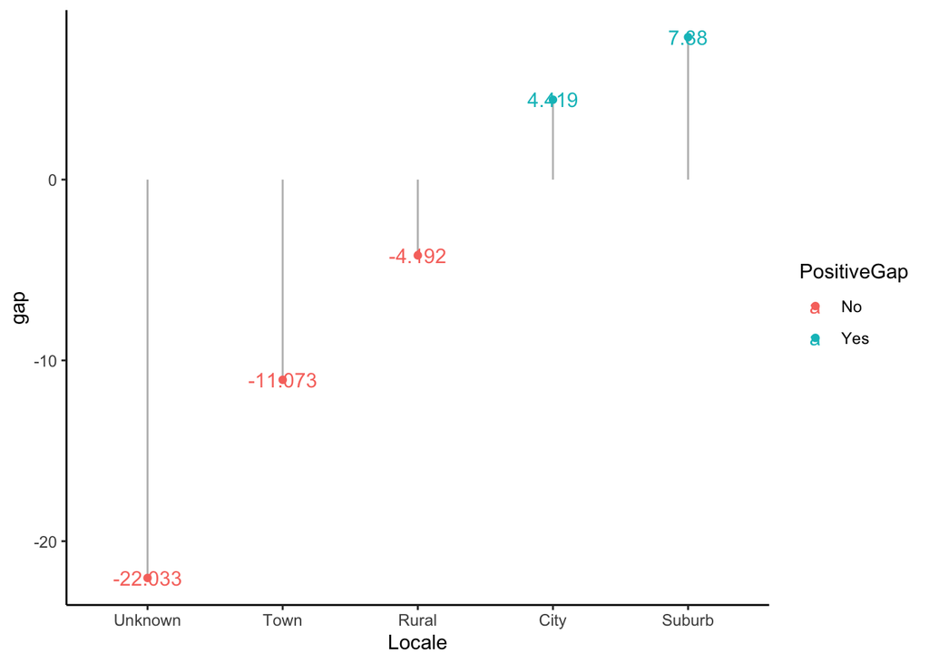

```r
base = ggplot(tableFreq, aes(x=Locale,y=gap,
                             color=PositiveGap,
                             label = round(gap,3))) #label

base = base + theme_classic()
base= base + scale_x_discrete(limits=localesOrd)

lolliplot1=base + geom_segment(aes(y = 0, yend = gap,
                                   x = Locale, xend = Locale),
                               color = "gray")

lolliplot2=lolliplot1 + geom_point()

lolliplot2 + geom_text()
```

You can avoid the overlaping symbols in the legend by using:

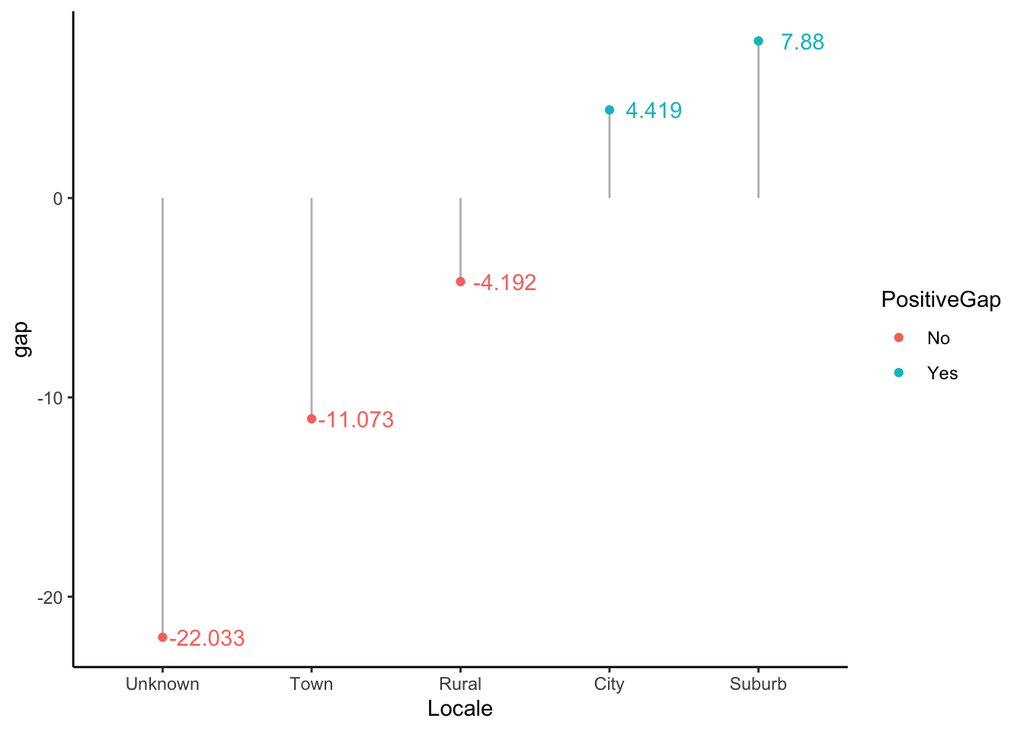

```r
lolliplot3= lolliplot2 + geom_text(nudge_x=0.3,#to the right
                                   show.legend = FALSE)
lolliplot3
```

You can add the reference line:

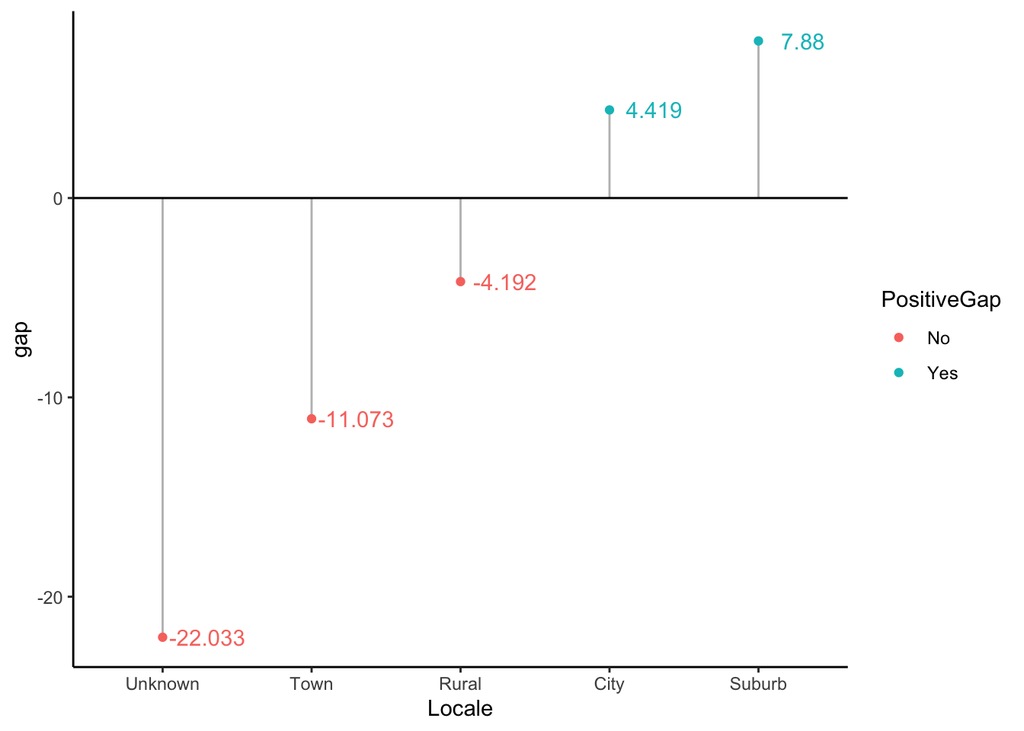

```r
lolliplot4 = lolliplot3 + geom_hline(yintercept = 0)
lolliplot4
```

You can get rid of extra info:

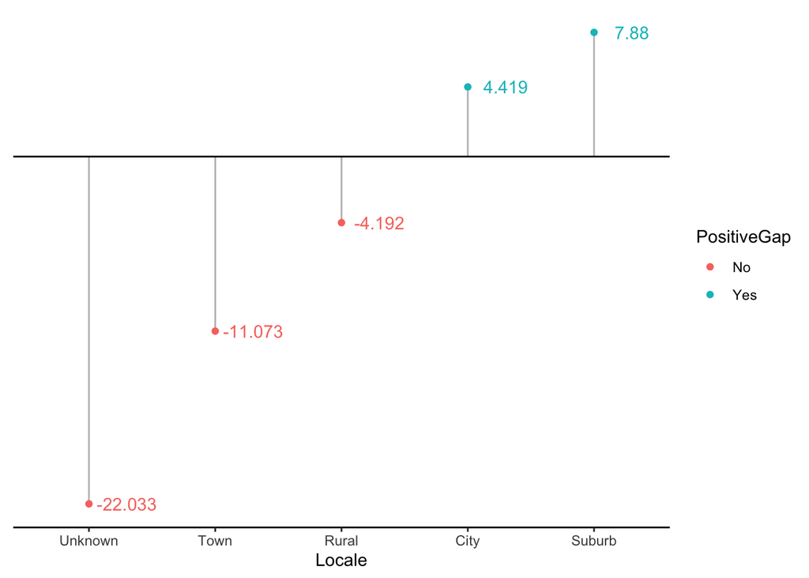

```r
# calling "element_blank()"
lolliplot5 = lolliplot4 + theme(axis.ticks.y = element_blank(),
                                axis.title.y = element_blank(),
                                axis.line.y = element_blank(),
                                axis.text.y = element_blank())
lolliplot5
```

Less elements:

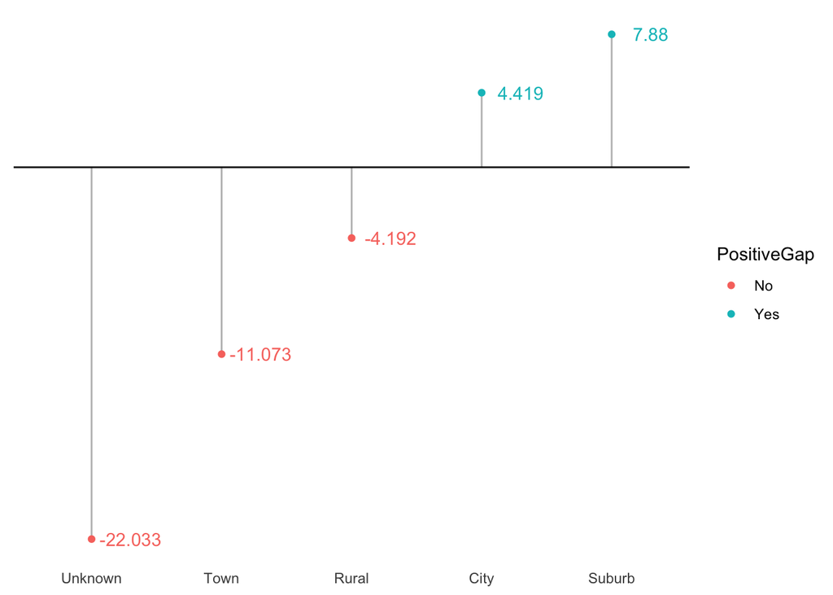

```r
# more "element_blank()"

lolliplot6=lolliplot5 + theme(axis.ticks.x = element_blank(),
                                axis.title.x = element_blank(),
                                axis.line.x = element_blank()
                              )
lolliplot6
```

Moving the legend within the plot area:

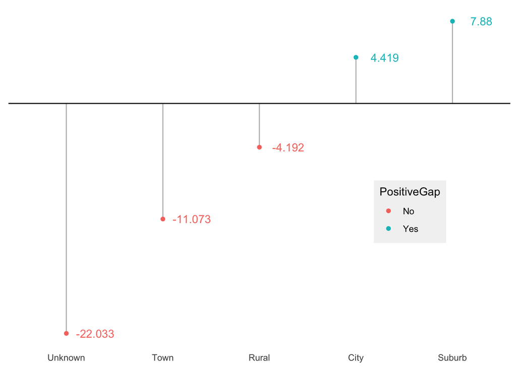

```r
lolliplot7= lolliplot6 + theme(legend.position = c(0.8,0.4),
                               legend.background = element_rect(fill='grey95'))
lolliplot7
```

What about this:

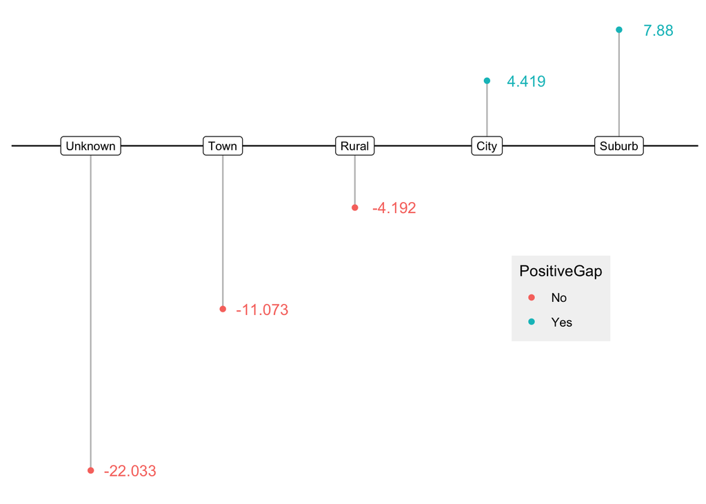

```r
lolliplot8 = lolliplot7 +  geom_label(aes(label=localesOrd),
                                      color ='black ',
                                      size =3,
                                      y=0,
                                      show.legend = FALSE ) +
             theme(axis.text.x = element_blank())
lolliplot8
```

Go to table of contents.

### 2. Visualization for ordinal variables

For this section, we will use the variable that tells us the highest grade offered in a school. A simple exploration gives:

```r
table(eduwa$High.Grade,exclude = 'nothing')
```

```
##
##  PK  KG   1   2   3   4   5   6   7   8   9  10  11  12  13
##  82   7   6  16  19  45 755 266  11 427  15   7   5 757   9
```

Being a categorical variable, the default option is again the bar plot. So let’s prepare the frequency table as a data frame:

```r
frqTabO=as.data.frame(prop.table(table(eduwa$High.Grade)))
names(frqTabO)=c('grade','pct')
frqTabO
```

```
##    grade         pct
## 1     PK 0.033786568
## 2     KG 0.002884219
## 3      1 0.002472188
## 4      2 0.006592501
## 5      3 0.007828595
## 6      4 0.018541409
## 7      5 0.311083642
## 8      6 0.109600330
## 9      7 0.004532344
## 10     8 0.175937371
## 11     9 0.006180470
## 12    10 0.002884219
## 13    11 0.002060157
## 14    12 0.311907705
## 15    13 0.003708282
```

Notice that have previously set the right data type for this variable. Now, we can use ggplot:

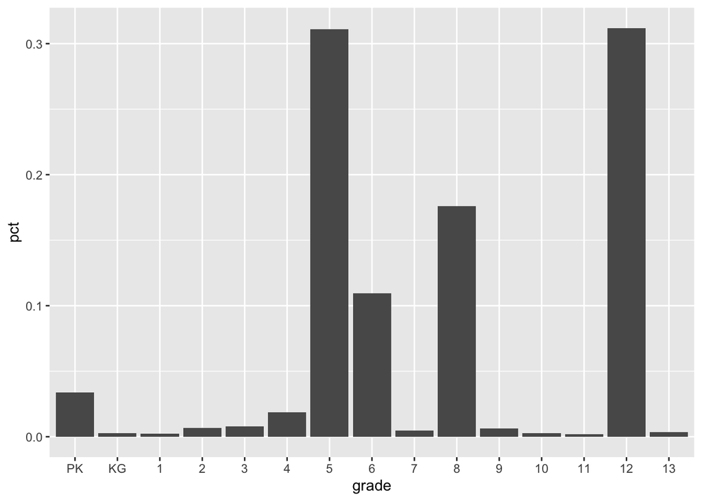

```r
base = ggplot(frqTabO,aes(x=grade,y=pct))
base + geom_bar(stat = 'identity')
```

The x-values in this variable have **order**. That is, there is an increasing level in the values. Whenever we have an ordering, besides *concentration* we can visualize **symmetry**: if there is bias towards lower or higher values.

Bar plots help you see concentration and symmetry, but we have an alternative way to clearly detect symmetry, via **boxplots**:

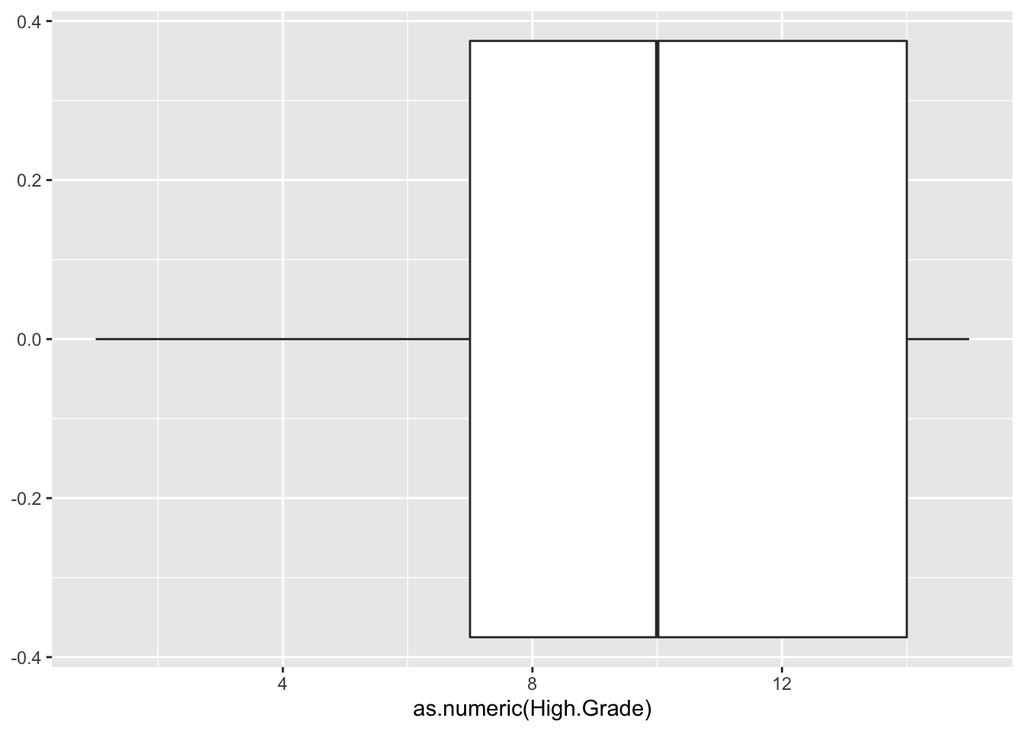

```r
# boxplots do not use frequency tables

# "as.numeric" produces turns levels of the factor into numbers
basebox1 = ggplot(eduwa, aes(y=as.numeric(High.Grade)))
box1 = basebox1 + geom_boxplot() + coord_flip() # to show it horizontally

box1
```

You have symmetry when the distance of those whiskers to the box is the same, and when the thick line is in the middle of the box. You can see that the values show a negative asymmetry (tail to the left).

Box plots expect a numeric value as an input, but we have an ordered categorical, so we used the *as.numeric()* function. However, that eliminated the levels we saw in the previous bar plot; we can put the levels back in our plot:

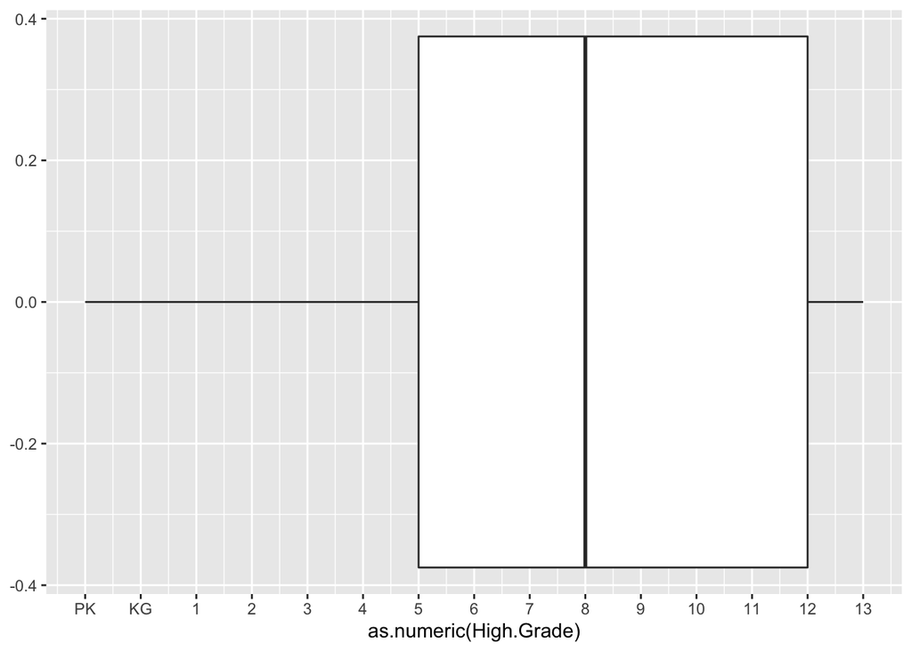

```r
# the labels use the original ordinal levels
ordLabels= levels(eduwa$High.Grade)

box2 = box1 + scale_y_continuous(labels=ordLabels,breaks=1:15)
box2
```

Box plots have important statistical information. The beginning and the ending of the box indicates the first (q1) and the third quantile (q75); and the thicker line in the middle represents the median. From the information retrieved, we know:

- 25% of the public Schools offer at most 5th GRADE.
- 50% of the public Schools offer at most 8th GRADE.
- 75% of the public Schools offer at most 12th GRADE (25% of the schools offer at least 12th grade).

### From numeric to ordinal

The variable “Free Lunch” is telling you how many students receive lunch in a school. If you request a summary you get:

```r
summary(eduwa$Free.Lunch)
```

```
##    Min. 1st Qu.  Median    Mean 3rd Qu.    Max.    NA's
##     0.0    52.0   140.0   179.4   245.2  1766.0     131
```

Then, when you see the minimum and max value, you can create groups by **cutting** the variable:

```r
eduwa$Free.LunchGroup=cut(eduwa$Free.Lunch,
                          breaks = c(0,100, 250, 500,1000,2000),
                          labels = c("100 and below","101-250","251-500","501-1000","1001 and above"))
```

This new variable has this table:

```r
table(eduwa$Free.LunchGroup)
```

```
##
##  100 and below        101-250        251-500       501-1000 1001 and above
##            790            840            448            101             11
```

Once you have “cut” a numerical variable, you can use ordinal plots.

Go to table of contents.